# Chapter3: Nonparametric Survival Curve Estimation

### Nonparametric estimation of the survival function

When modeling human or animal survival, it is hard to know what parametric family to choose, and often none of the available families has sufficient flexibility to model the actual shape of the distribution.  
パラメトリック推定は生存曲線が特定の確率分布をとるという強い仮定がある。  
Thus, in medical and health applications, nonparametric methods, which have the flexibility to account for the vagaries of the survival of living things, have considerable advantages.  
より流動的なノンパラ推定が好まれる  
The most widely used of these is the product-limit estimator, also known as the **Kaplan-Meier estimator**.  
This estimator is the product over the failure times of the conditional probabilities of surviving to the next failure time.  
Formally, it is given by

$$\hat{S}(t) = \prod_{t_i \leqq t} (1 - \hat{q}_i) = \prod_{t_i \leqq t} (1 - \frac{d_i}{n_i})$$

where $n_i$ is the number of subjects at risk at time $t_i$, and $d_i$ is the number of individuals who fail at that time.

```r
# Example:
(df <- tibble(
  patient = 1:6,
  survival = c(7, 6, 6, 5, 2, 4),
  status = c(0, 0, 1, 0, 1, 1)
))
```

```
## # A tibble: 6 x 3
##   patient survival status
##     <int>    <dbl>  <dbl>
## 1       1        7      0
## 2       2        6      0
## 3       3        6      1
## 4       4        5      0
## 5       5        2      1
## 6       6        4      1
```

```r
# Fit K-M method
fit <- surv_fit(Surv(survival, status) ~ 1, data = df)

(km_df <- surv_summary(fit) %>%
  mutate(q = (n.event / n.risk) %>% round(3), one_minus_q = (1 - q) %>% round(3),
         surv = surv %>% round(3)) %>%
  select(time, n.risk, n.event, n.censor, q, one_minus_q, surv))
```

```
##   time n.risk n.event n.censor     q one_minus_q  surv
## 1    2      6       1        0 0.167       0.833 0.833
## 2    4      5       1        0 0.200       0.800 0.667
## 3    5      4       0        1 0.000       1.000 0.667
## 4    6      3       1        1 0.333       0.667 0.444
## 5    7      1       0        1 0.000       1.000 0.444
```

The columns represent, respectively, the failure time, the number **n.risk** at risk at that time, the number **n.event** who fail at that time, the failure probability $q = \frac{n.event}{n.risk}$, the conditional survival probability $1-q$, and the cumulative product, which is the estimate of the survival probability.  
($q = \frac{n.event}{n.risk}$が$t = t_i$でイベント起こる確率なのでその時点の生存確率は$1-q$。これを累積してかけていくことで生存確率の推定を行っていく。$t = 4$の時点での生存確率は$0.833 \times 0.8 = 0.667$)  
Figure shows the Kaplan-Meier estimate of the survivor function using these data.

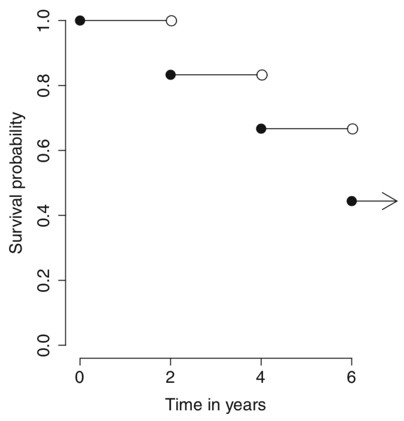

This function is a non-increasing step function, and the open and closed circles explicitly show the right-continuity. In practice, the Kaplan-Meier function is plotted as a step function, with the indicators of right-continuity not shown. The median survival time is at $t = 6$, which is the smallest time t such that $S(t) \leq 0.5$.

To obtain confidence limits for the product-limit estimator, we first use what is known as the **delta method** to obtain the variance of $\log{\hat{S(t)}}$.
$$\begin{align}
var(\log{\hat{S(t)}}) &= \displaystyle \sum_{t_i \leq t} var(\log{(1 - \hat{q})}) \\
&\approx \displaystyle \sum_{t_i \leq t} \frac{d_i}{n_i(n_i - d_i)}
\end{align}$$

To get the variance of $var(\hat{S(t)})$ itself, we use the **delta method** again to obtain  
(c.f delta method: if a random variable $X$ has mean $\mu$ and variance $\sigma^2$, them $g(X)$ will have approximate mean $g(\mu)$ and approximate variance $\sigma^2 \cdot [g'(\mu)]^2$)

$$\begin{align}
var(\hat{S(t)}) &= \exp(\log\hat{S(t)}) \\
&\approx var(\log\hat{S(t)}) \cdot \{ \exp{(\log\hat{S(t)})} \}^2 \\
&= [\hat{S(t)}]^2 \sum_{t_i \leq t} \frac{d_i}{n_i(n_i - d_i)}
\end{align}$$
Unfortunately, confidence intervals computed based on this variance may extend above one or below zero. (この信頼区間だと生存確率の区間が[0,1]を越えることがある。)
While one could truncate them at one and zero, a more satisfying approach is to find confidence intervals for the complementary log-log transformation of $\hat{S(t)}$ as follow. (この場合信頼区間が1を越えることはない)

$$\begin{align}
var(\log{[-\log{\hat{S(t)}}]}) &\approx var(\log(\hat{S(t)})) \cdot ( -1 / \log\hat{S(t)})^2 \\
&= \frac{1}{[\log{\hat{S(t)}}]^2} \sum_{t_i \leq t} \frac{d_i}{n_i(n_i - d_i)}
\end{align}$$
Obtain estimates of the Kaplan-Meier estimator in R for the data in Table 1, we first load the `survival` library, and then enter the data.
Note that the `Surv` function produces a special structure for censored survival data. (7+: time = 7で打ち切り、6: t = 6でイベント)

```r
# Apply K-M method
Surv(df$survival, df$status)
```

```
## [1] 7+ 6+ 6  5+ 2  4
```

For the estimation itself we use the `survminer::surv_fit` function,  
To compute confidence intervals based on our preferred method, the complementary log-log transformation, we have to explicitly specify that.

```r
# View log_fit and log_log_fit
(log_fit <- surv_fit(Surv(survival, status) ~ 1, data = df, conf.type = "log"))  # default
```

```
## Call: survfit(formula = Surv(survival, status) ~ 1, data = structure(list(
##     patient = 1:6, survival = c(7, 6, 6, 5, 2, 4), status = c(0,
##     0, 1, 0, 1, 1)), .Names = c("patient", "survival", "status"
## ), row.names = c(NA, -6L), class = c("tbl_df", "tbl", "data.frame"
## )), conf.type = "log")
##
##       n  events  median 0.95LCL 0.95UCL
##       6       3       6       4      NA
```

```r
(log_log_fit <- surv_fit(Surv(survival, status) ~ 1, data = df, conf.type = "log-log"))
```

```
## Call: survfit(formula = Surv(survival, status) ~ 1, data = structure(list(
##     patient = 1:6, survival = c(7, 6, 6, 5, 2, 4), status = c(0,
##     0, 1, 0, 1, 1)), .Names = c("patient", "survival", "status"
## ), row.names = c(NA, -6L), class = c("tbl_df", "tbl", "data.frame"
## )), conf.type = "log-log")
##
##       n  events  median 0.95LCL 0.95UCL
##       6       3       6       2      NA
```

```r
# View summary of log_fit and log_log_fit
# confidence intervals above is truncated at one
summary(log_fit)
```

```
## Call: survfit(formula = Surv(survival, status) ~ 1, data = structure(list(
##     patient = 1:6, survival = c(7, 6, 6, 5, 2, 4), status = c(0,
##     0, 1, 0, 1, 1)), .Names = c("patient", "survival", "status"
## ), row.names = c(NA, -6L), class = c("tbl_df", "tbl", "data.frame"
## )), conf.type = "log")
##
##  time n.risk n.event survival std.err lower 95% CI upper 95% CI
##     2      6       1    0.833   0.152        0.583            1
##     4      5       1    0.667   0.192        0.379            1
##     6      3       1    0.444   0.222        0.167            1
```

```r
summary(log_log_fit)
```

```
## Call: survfit(formula = Surv(survival, status) ~ 1, data = structure(list(
##     patient = 1:6, survival = c(7, 6, 6, 5, 2, 4), status = c(0,
##     0, 1, 0, 1, 1)), .Names = c("patient", "survival", "status"
## ), row.names = c(NA, -6L), class = c("tbl_df", "tbl", "data.frame"
## )), conf.type = "log-log")
##
##  time n.risk n.event survival std.err lower 95% CI upper 95% CI
##     2      6       1    0.833   0.152       0.2731        0.975
##     4      5       1    0.667   0.192       0.1946        0.904
##     6      3       1    0.444   0.222       0.0662        0.785
```

```r
# View fit by survminer::surv_summary
surv_summary(log_fit)
```

```
##   time n.risk n.event n.censor      surv   std.err upper     lower
## 1    2      6       1        0 0.8333333 0.1825742     1 0.5826548
## 2    4      5       1        0 0.6666667 0.2886751     1 0.3786065
## 3    5      4       0        1 0.6666667 0.2886751     1 0.3786065
## 4    6      3       1        1 0.4444444 0.5000000     1 0.1668079
## 5    7      1       0        1 0.4444444 0.5000000     1 0.1668079
```

```r
surv_summary(log_log_fit)
```

```
##   time n.risk n.event n.censor      surv   std.err     upper      lower
## 1    2      6       1        0 0.8333333 0.1825742 0.9747124 0.27312285
## 2    4      5       1        0 0.6666667 0.2886751 0.9044342 0.19461664
## 3    5      4       0        1 0.6666667 0.2886751 0.9044342 0.19461664
## 4    6      3       1        1 0.4444444 0.5000000 0.7849084 0.06618675
## 5    7      1       0        1 0.4444444 0.5000000 0.7849084 0.06618675
```

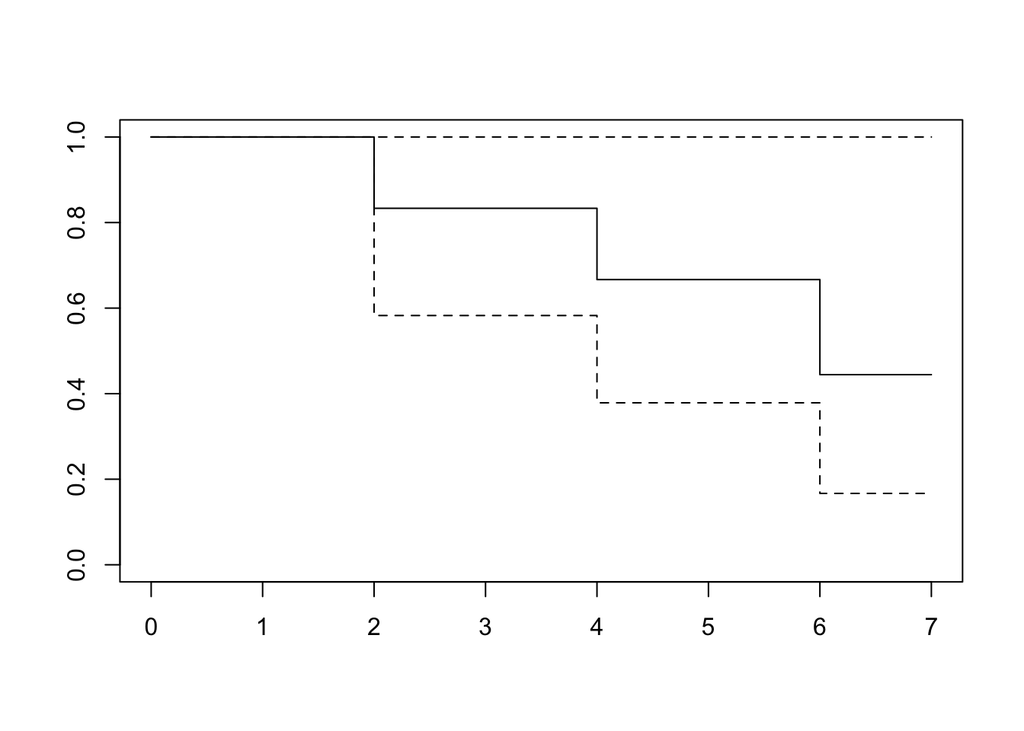

```r
# Plot fit
plot(log_fit)
```

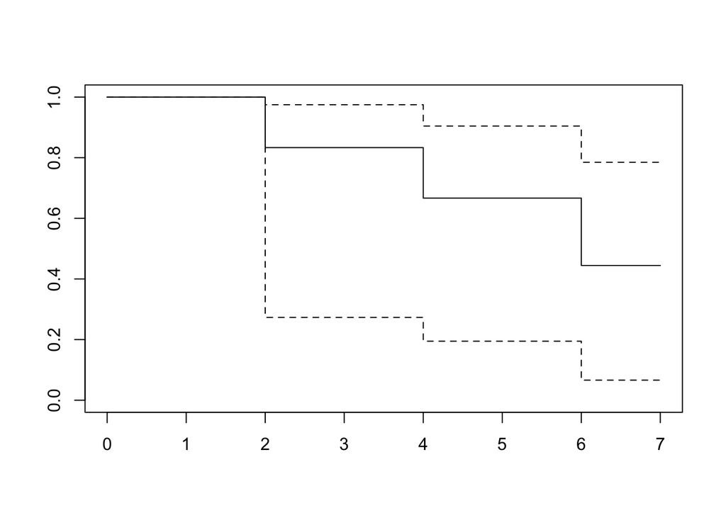

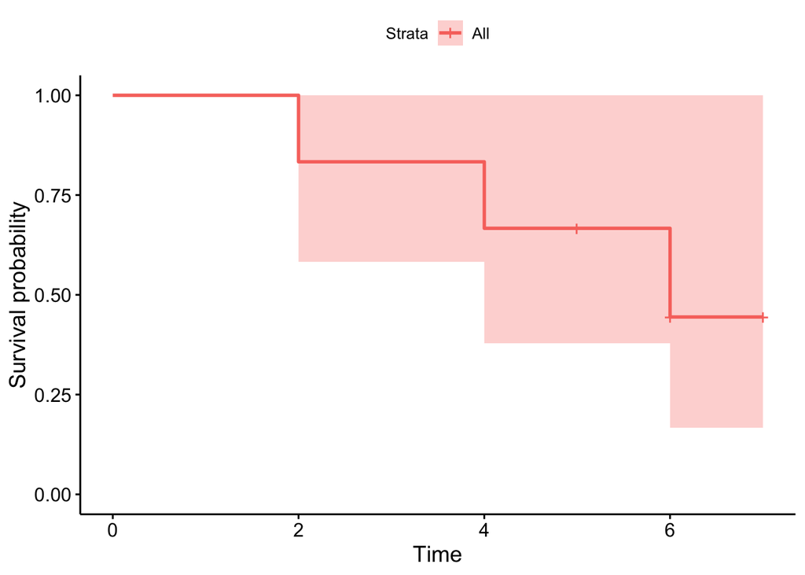

```r
plot(log_log_fit)

# Plot by ggsurvplot
ggsurvplot(log_fit)
```

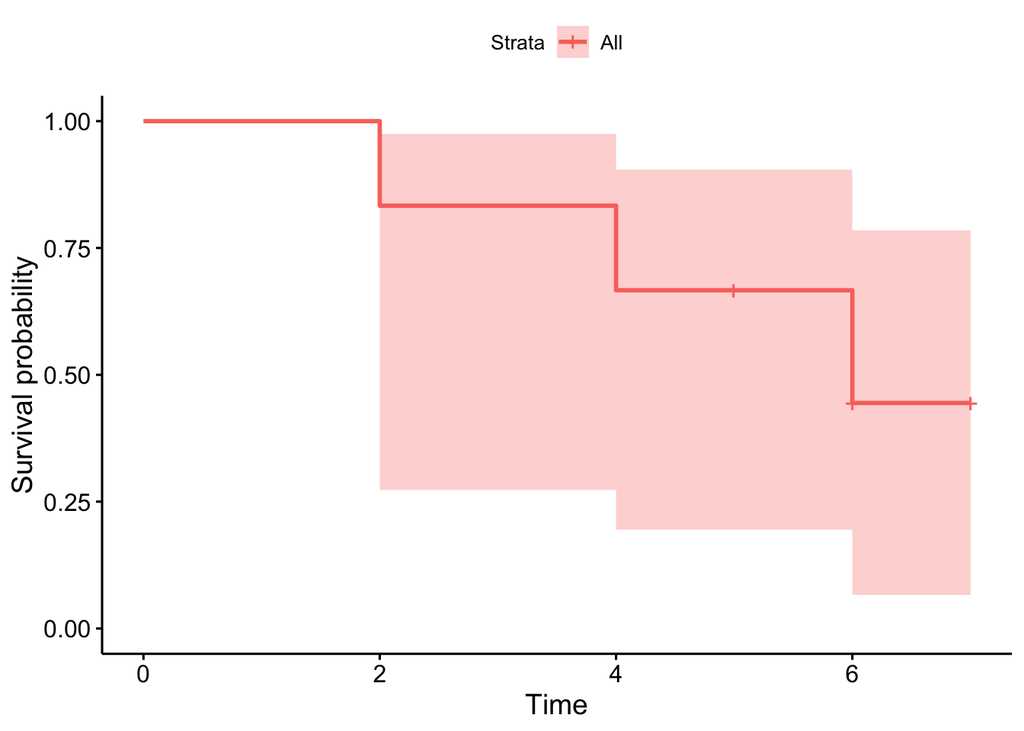

```r
ggsurvplot(log_log_fit)
```

An alternative estimator of the survival function is known as the **Nelson–Aalen estimator**.  
It is based on the relationship of the survival function to the hazard function. An estimate of the cumulative hazard function is the sum of the estimated hazards up to a time $t_i$:

$$H(t) = \displaystyle \sum_{t \leq t_i} \frac{d_i}{n_i}$$
and the survival function estimate is simply

$$S(t) = e^{-H(t)}$$

In R, the **Nelson–Altschuler estimate** may be obtained using the `surv_fit` function with the option `type = "fh"`, the letters “fh” being taken from the initials of **Fleming and Harrington**:

```r
# Fit by Nelson-Aalen
(fit_fh <- surv_fit(Surv(survival, status) ~ 1, data = df, conf.type = "log-log", type = "fh"))
```

```
## Call: survfit(formula = Surv(survival, status) ~ 1, data = structure(list(
##     patient = 1:6, survival = c(7, 6, 6, 5, 2, 4), status = c(0,
##     0, 1, 0, 1, 1)), .Names = c("patient", "survival", "status"
## ), row.names = c(NA, -6L), class = c("tbl_df", "tbl", "data.frame"
## )), conf.type = "log-log", type = "fh")
##
##       n  events  median 0.95LCL 0.95UCL
##       6       3       6       2      NA
```

```r
# View summary
surv_summary(fit_fh)
```

```
##   time n.risk n.event n.censor      surv   std.err     upper     lower
## 1    2      6       1        0 0.8464817 0.1666667 0.9767962 0.3063036
## 2    4      5       1        0 0.6930406 0.2603417 0.9128535 0.2288939
## 3    5      4       0        1 0.6930406 0.2603417 0.9128535 0.2288939
## 4    6      3       1        1 0.4965853 0.4229526 0.8072000 0.1014942
## 5    7      1       0        1 0.4965853 0.4229526 0.8072000 0.1014942
```

```r
# View data
surv_summary(fit_fh) %>%
  mutate(hazard = (n.event / n.risk) %>% round(3), cum_hazard = cumsum(hazard),
         surv = round(surv, 3)) %>%
  select(time, starts_with("n."), ends_with("hazard"), surv)
```

```
##   time n.risk n.event n.censor hazard cum_hazard  surv
## 1    2      6       1        0  0.167      0.167 0.846
## 2    4      5       1        0  0.200      0.367 0.693
## 3    5      4       0        1  0.000      0.367 0.693
## 4    6      3       1        1  0.333      0.700 0.497
## 5    7      1       0        1  0.000      0.700 0.497
```

We now consider data from an actual clinical trial. The data set `gastricXelox` is a Phase II (single sample) clinical trial of the chemotherapeutic agent Xelox administered to patients with advanced gastric cancer prior to surgery. The primary outcome of interest is “progression-free survival.(PFS)”

```r
head(gastricXelox)
```

```
##   timeWeeks delta
## 1         4     1
## 2         8     1
## 3         8     1
## 4         8     1
## 5         9     1
## 6        11     1
```

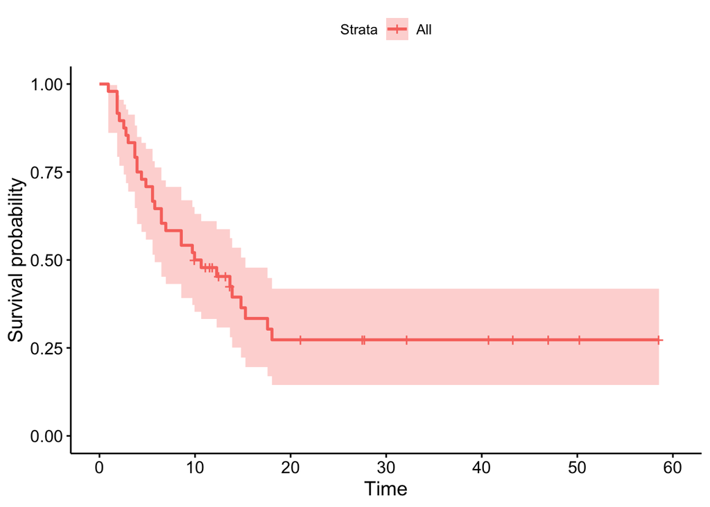

```r
# Convert weeks to month
df_xelox <- gastricXelox %>%
  mutate(timeWeeks = timeWeeks * 7 / 30.25) %>%
  rename(month = timeWeeks)

# Fit k-m method
km_xelox <- surv_fit(Surv(month, delta) ~ 1, data = df_xelox, conf.type = "log-log")

# Plot k_m curve
ggsurvplot(km_xelox)
```

### Finding the median survival and a confidence interval for the median

Formally, the median survival time may be defined as $\hat{t_{med}} = \inf{ \{t: \hat{S(t)}\leq 0.5 \} }$ ;  
that is, it is the smallest *t* such that the survival function is less than or equal to 0.5.  
To find a $1-\alpha$ confidence interval for the median, we consider the following inequality:

$$-z_{\alpha / 2} \leq
\frac{g\{ \hat{S(t)} \} - g(0.5)}{\sqrt{var[g\{ \hat{S(t)} \}]}} \leq
z_{\alpha}$$

where $g(u) = \log{[\log(u)]}$ and $var[g\{ \hat{S(t)} \}]$ is given by before Eq.  
To obtain a 95% confidence interval, we search for the smallest value of *t* such that the middle of the expression is at least -1.96 (for the lower limit) and the largest value of *t* such that the middle expression does not exceed 1.96 (for the upper limit).  
By default, the `surv_fit` function prints out 95% confidence limits for the median.  
To obtain the median survival time for the gastric cancer data, and a 95% confidence interval, just enter the result of the `surv_fit` function:

```r
km_xelox
```

```
## Call: survfit(formula = Surv(month, delta) ~ 1, data = structure(list(
##     month = c(0.925619834710744, 1.85123966942149, 1.85123966942149,
##     1.85123966942149, 2.08264462809917, 2.54545454545455, 2.77685950413223,
##     3.00826446280992, 3.70247933884298, 3.70247933884298, 3.93388429752066,
##     3.93388429752066, 4.39669421487603, 4.8595041322314, 5.55371900826446,
##     5.55371900826446, 5.78512396694215, 6.47933884297521, 6.47933884297521,
##     6.94214876033058, 8.56198347107438, 8.56198347107438, 9.71900826446281,
##     9.9504132231405, 9.9504132231405, 10.6446280991736, 11.1074380165289,
##     11.5702479338843, 11.801652892562, 12.2644628099174, 12.495867768595,
##     13.1900826446281, 13.6528925619835, 13.6528925619835, 13.8842975206612,
##     14.8099173553719, 15.2727272727273, 17.5867768595041, 18.0495867768595,
##     21.0578512396694, 27.5371900826446, 27.7685950413223, 32.1652892561983,
##     40.7272727272727, 43.2727272727273, 46.9752066115703, 50.2148760330578,
##     58.5454545454545), delta = c(1L, 1L, 1L, 1L, 1L, 1L, 1L,
##     1L, 1L, 1L, 1L, 1L, 1L, 1L, 1L, 1L, 1L, 1L, 1L, 1L, 1L, 1L,
##     1L, 1L, 0L, 1L, 0L, 0L, 0L, 1L, 0L, 0L, 0L, 1L, 1L, 1L, 1L,
##     1L, 1L, 0L, 0L, 0L, 0L, 0L, 0L, 0L, 0L, 0L)), class = "data.frame", row.names = c(NA,
## -48L), .Names = c("month", "delta")), conf.type = "log-log")
##
##       n  events  median 0.95LCL 0.95UCL
##   48.00   32.00   10.30    5.79   15.27
```

Here we see that the median PFS time is 10.30 months, and a 95% confidence interval ranges from 5.79 to 15.27 months.

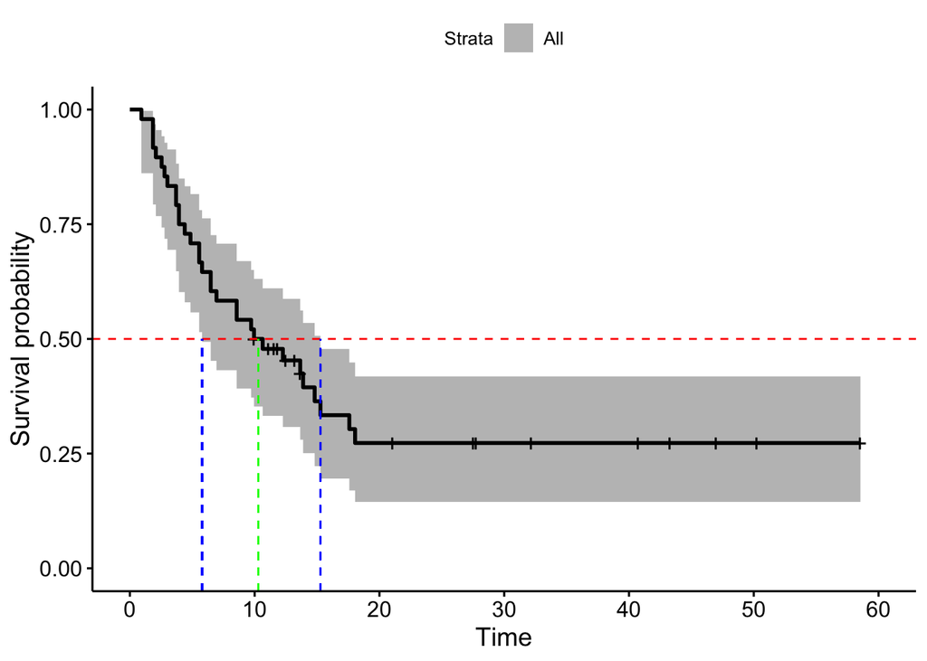

```r
# extract MST and 95% C.I.
median_ci <- map_dbl(c("median", "lower", "upper"),
                     ~ surv_median(km_xelox) %>% pull(.x))

ggsurvplot(km_xelox, color = "black") %++%
  geom_hline(aes(yintercept = 0.5), color = "red", linetype = "dashed") %++%
  geom_segment(aes(x = median_ci[1], xend = median_ci[1], y = -Inf, yend = 0.5),
               color = "green", linetype = "dashed") %++%
  geom_segment(aes(x = median_ci[2], xend = median_ci[2], y = -Inf, yend = 0.5),
               color = "blue", linetype = "dashed") %++%
  geom_segment(aes(x = median_ci[3], xend = median_ci[3], y = -Inf, yend = 0.5),
               color = "blue", linetype = "dashed")
```

### Median follow-Up time

One measure of the quality of a clinical trial is the duration of follow-up, as measured by the median follow-up time. This is a measure that captures how long, on average, patients have been followed.  
A simple definition is to consider all of the survival times, whether censored or not, and find the median. A disadvantage of this is that a trial with many early deaths, but a long observation period, would appear not to have a long median follow-up time. (単純に打ち切り関係なく観察期間の中央値をmedian follow-up timeとすると長期間の研究かつ早期脱落が多いとmedian follow-up timeがかなり小さくなってしまう)

```r
# Simple median follow-up
df_xelox %>%
  summarise(median = median(month))
```

```
##     median
## 1 9.950413
```

A perhaps better way of looking at median survival is the **“potential” median survival**.  
To obtain this estimate, one first switches the censoring and death indicators, so that a “censored” observation is the “event”, while a death is viewed as a censored observation, in the sense that the observation time would have been much longer had the patient not died. (打ち切りをfollow-up終了のイベント、イベントをfollow-up終了の打ち切りと捉える)  
One then computes the Kaplan- Meier “survival” estimate using these reversed censoring indicators, and finds the median survival, as discussed in the previous section. This method is also known as the **“reverse” Kaplan-Meier**.

```r
# Potential follow-up
survfit(Surv(month, delta == 0) ~ 1, data = df_xelox)
```

```
## Call: survfit(formula = Surv(month, delta == 0) ~ 1, data = df_xelox)
##
##       n  events  median 0.95LCL 0.95UCL
##    48.0    16.0    27.8    21.1    50.2
```

The simple median follow-up time is only 9.95 months, whereas the potential follow-up time is 27.8 months.

### Obtaining a smoothed hazard and survival function estimate

The **Nelson-Altschuler estimate** of the cumulative hazard function at time $t_i$, given in the previous section, is the sum of these hazard estimates up to that time. However, this estimate of the hazard function is quite unstable from one time to the next, and thus is of limited value in illustrating the true shape of the hazard function. (KM推定やNAA推定はstep-functionでありハザードの推定にはやや限界がある…)  
A better way to visualize the hazard function estimate is by using a **kernel smoother**. A kernel is a function $K(u)$, which we center at each failure time. Typically we choose a smooth-shaped kernel, with the amount of smoothing controlled by a parameter *b*.  
(カーネル関数はdensity plotと同じ原理で確率密度関数fからとった標本より作成したカーネル関数の組み合わせによりもともとの確率分布を推定する方法)

The estimate of the hazard function is given by

$$\hat{h(t)} = \frac{1}{b} \displaystyle \sum_{i = 1}^{D} K(\frac{t - t_{(i)}}{b}) \frac{d_i}{n_i}$$

where $t_{(1)}<t_{(2)}<\cdot \cdot \cdot<t_{(D)}$ are distinct ordered failure times, the subscript “*(i)*” in $t_{(i)}$ indicates that this is the *i*’th ordered failure time, $d_i$ is the number of deaths at time $t_{(i)}$, and $n_i$ is the number at risk at that time.  
Note that in the special case where the kernel function $K(u) = 1$ when *u* is a failure time and zero elsewhere, this estimator is just the **Nelson-Altschuler hazard estimator**.  
While there are many ways to define the kernel function, a common one is the **Epanechnikov kernel**, $K(u) = \frac{3}{4} (1 - u^2)$, defined for $-1\leq u \leq 1$, and zero elsewhere.  
In the above formula for the hazard, there is one kernel function placed at each failure time, scaled by the smoothing parameter *b*. Larger values of *b* result in wider kernel functions, and hence more smoothing. (b:バンド幅が広くなるとよりsmoothになる)

This is illustrated in below Fig. Here the three failure times $t = 2, 4, 6$ are indicated by gray triangles, and the kernels, adjusted for height as in equation, are dashed gray.  
The sum, the smoothed estimate of the hazard, is given by the blue curve.

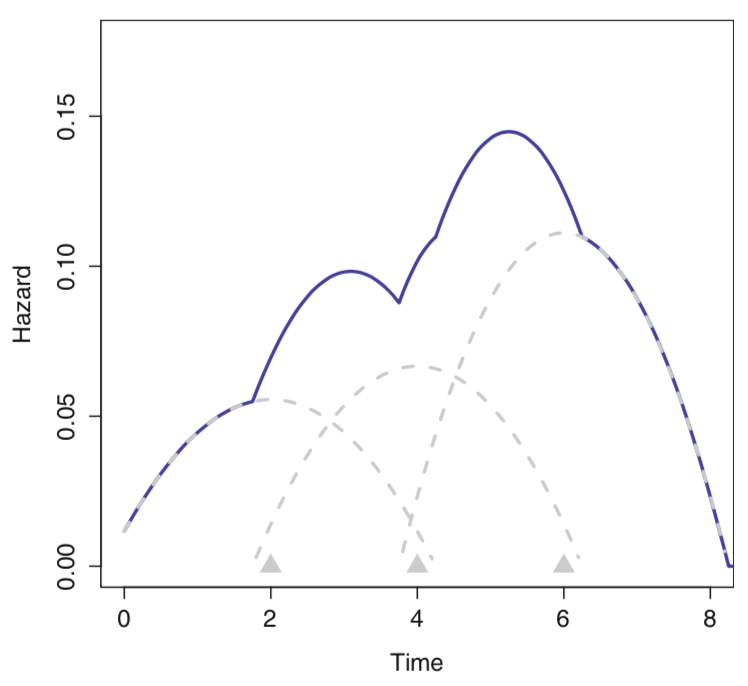

In the R package, there is a library `muhaz` for estimating and plotting nonparametric hazard functions.

```r
library(muhaz)
df
```

```
## # A tibble: 6 x 3
##   patient survival status
##     <int>    <dbl>  <dbl>
## 1       1        7      0
## 2       2        6      0
## 3       3        6      1
## 4       4        5      0
## 5       5        2      1
## 6       6        4      1
```

```r
# Estimate by karnel
karnel_df <- muhaz(df$survival, df$status, # failure times and censoring indicators
                   max.time = 8,
                   bw.grid = 2.25,         # parameter b is specified by "bw.grid = 2.25"
                   bw.method = "global",   # constant smoothing parameter is use for all times
                   b.cor = "none")         # set to “none” indicating that no boundary correction is to be done
```

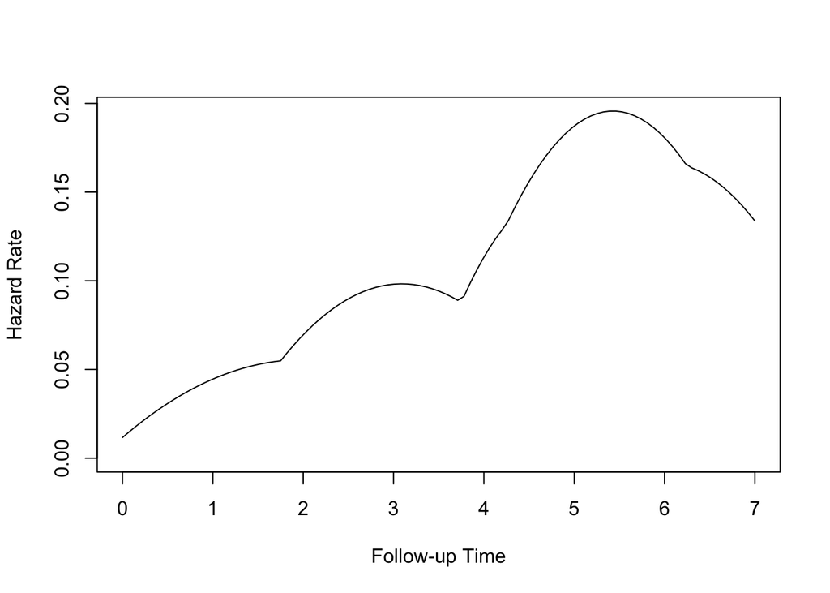

```r
# Plot karnel hazard
plot(karnel_df)
```

We now illustrate estimation of the hazard function for the `gastricXelox` data.  
First, let us divide time into equal intervals of width 5 months, and observe the number of events (progression or death) $d_i$ and the number of patients at risk each interval, $n_i$; the hazard estimate for that interval is $h_i = d_i /n_i$.  
The hazard estimate using this method may be obtained using the `pehaz` function:

```r
# Hazard estimate
pe5_hazard <- pehaz(df_xelox$month, df_xelox$delta,
                    width = 5, max.time = 20)  # step function for 5-month intervals (5ヶ月毎のハザード)
```

```
##
## max.time= 20
## width= 5
## nbins= 4
```

```r
pe1_hazard <- pehaz(df_xelox$month, df_xelox$delta,
                    width = 1, max.time = 20)  # step function for 1-month intervals (1ヶ月毎のハザード)
```

```
##
## max.time= 20
## width= 1
## nbins= 20
```

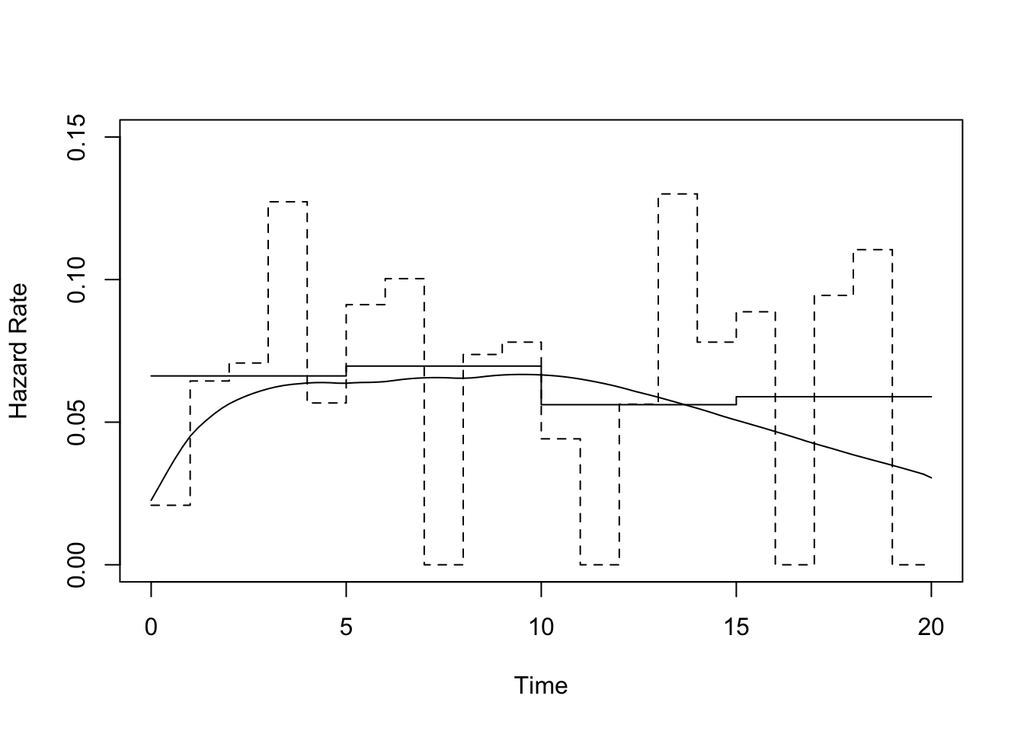

```r
smooth_hazard <- muhaz(df_xelox$month, df_xelox$delta,
                       bw.smooth=20, b.cor="left", max.time=20) # smooth-estimation

plot(pe5_hazard, ylim=c(0,0.15), col="black")
lines(pe1_hazard)
lines(smooth_hazard)
```

One use of smoothing the hazard function is to obtain a smooth estimate of the survival function, using there lationship $\hat{S(t)} = e^{-\int_{0}^{\infty \hat{h(u)}du} }$. To get estimation we need to extract the hazard estimate and list of times at which the hazard is estimated as follows:

```r
# extract hazard estimation
smooth_hazard_xelox <- smooth_hazard$haz.est

# extract time
smooth_time_xelox <- smooth_hazard$est.grid

# calculate survival
smooth_survival_xelox <- exp(cumsum(-smooth_hazard_xelox[1:length(smooth_hazard_xelox) - 1]) * diff(smooth_time_xelox))
```

We may compare our smoothed survival estimate to the Kaplan-Meier estimate as follows:

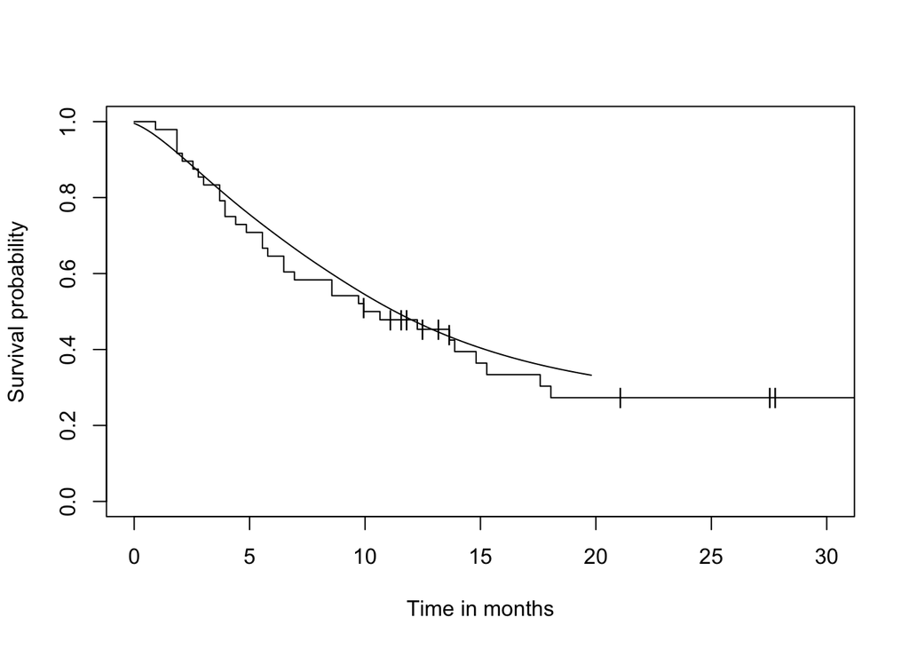

```r
plot(km_xelox, conf.int = F, mark = "|",
     xlab = "Time in months", xlim = c(0, 30), ylab = "Survival probability")
lines(smooth_survival_xelox ~ smooth_time_xelox[1:(length(smooth_time_xelox) - 1)])
```

### Left Truncation

While we have focused on right censoring as a type of incomplete data, there is another type of incompleteness, called “left truncation,” which we are sometimes faced with.  
To understand left truncation, consider again the data from `df`.

```r
(df2 <- df %>%
  mutate(diagnosis = c(-2, -3, -5, -3, -2, -5),
         surv_from_diag = abs(diagnosis) + survival,
         patient = as.character(patient)) %>%
  bind_rows(tibble(patient = "X", survival = -2, status = 1, diagnosis = -4, surv_from_diag = NA)) %>%
  select(patient, diagnosis, everything())
  )
```

```
## # A tibble: 7 x 5
##   patient diagnosis survival status surv_from_diag
##   <chr>       <dbl>    <dbl>  <dbl>          <dbl>
## 1 1              -2        7      0              9
## 2 2              -3        6      0              9
## 3 3              -5        6      1             11
## 4 4              -3        5      0              8
## 5 5              -2        2      1              4
## 6 6              -5        4      1              9
## 7 X              -4       -2      1             NA
```

Now, instead of examining the time from entry into the clinical trial until censoring or death, let us use as the time origin the time of diagnosis. The time from diagnosis to death (or censoring) may be of more practical interest than the time from entry into the trial to death.  
To get this additional information, we interview each patient when he or she enters the trial to determine the time that the disease was diagnosed. (“backward recurrence times”)  
For example, Patient 1 was diagnosed 2 time units before entry into the trial, and was censored at time 7, which refers to the time from entry into the trial until censoring.  
Then the total time from diagnosis to censoring is $7 + 2 = 9$ time units.

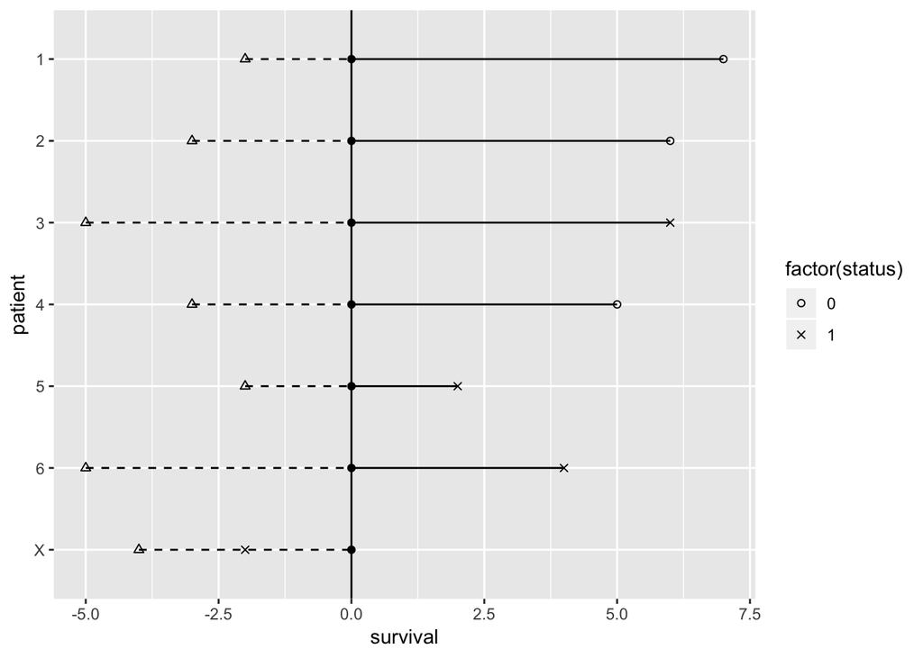

```r
# Plot df2 data
ggplot(df2) +
  geom_point(aes(x = survival, y = patient, shape = factor(status))) +
  geom_point(aes(x = 0, y = patient), shape = 19) +
  geom_point(aes(x = diagnosis, y = patient), shape = 2) +
  geom_segment(data = slice(df2, -7), aes(x = 0, xend = survival, y = patient, yend = patient)) +
  geom_segment(aes(x = diagnosis, xend = 0, y = patient, yend = patient), linetype = "dashed") +
  geom_vline(xintercept = 0) +
  scale_shape_manual(values = c(1, 4)) +
  scale_y_discrete(limits = c("X", "6", "5", "4", "3", "2", "1"))
```

Entry into the trial is still at time 0, but we have added diagnosis times, indicated by triangles. “Patient X,” as discussed in `df2`.

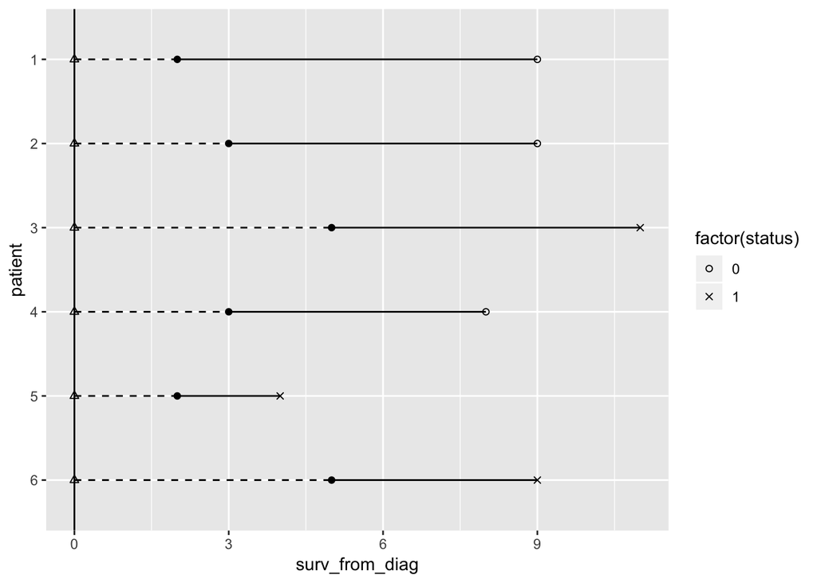

```r
# Realign so that the time of diagnosis is time 0
(left_trunc_plot <- ggplot(slice(df2, -7)) +
  geom_point(aes(x = surv_from_diag, y = patient, shape = factor(status))) +
  geom_point(aes(x = -diagnosis, y = patient), shape = 19) +
  geom_point(aes(x = 0, y = patient), shape = 2) +
  geom_segment(aes(x = -diagnosis, xend = surv_from_diag, y = patient, yend = patient)) +
  geom_segment(aes(x = 0, xend = -diagnosis, y = patient, yend = patient), linetype = "dashed") +
  scale_shape_manual(values = c(1, 4)) +
  geom_vline(xintercept = 0) +
  scale_y_discrete(limits = c("6", "5", "4", "3", "2", "1")))
```

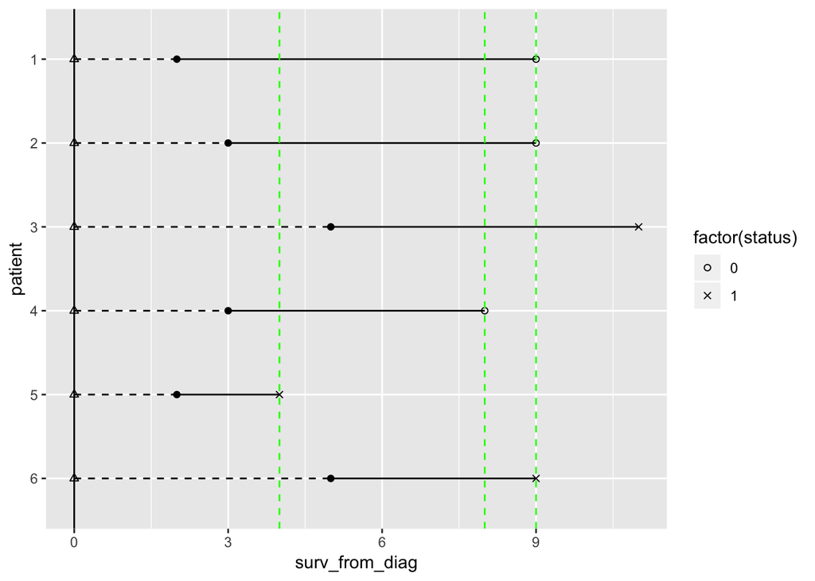

```r
left_trunc_plot +
  geom_vline(aes(xintercept = 4), color = "green", linetype = "dashed") +
  geom_vline(aes(xintercept = 8), color = "green", linetype = "dashed") +
  geom_vline(aes(xintercept = 9), color = "green", linetype = "dashed")
```

In R, we may obtain both estimates as follows:

```r
df2_complete <- na.omit(df2) %>%
  mutate(entry = -diagnosis)

# KM method
left_trunc_km <- surv_fit(Surv(entry, surv_from_diag, status, type = "counting") ~ 1,
                          data = df2_complete, conf.type="none")

# NAA method
left_trunc_naa <- surv_fit(Surv(entry, surv_from_diag, status, type = "counting") ~ 1,
                           data = df2_complete, type="fleming-harrington", conf.type="none")

# Make summary of survfit
(left_trunc_mod_df <- tibble(time = left_trunc_km$time,
                             n.risk = left_trunc_km$n.risk,
                             n.event = left_trunc_km$n.event,
                             hazard = n.event / n.risk) %>%
                      filter(n.event != 0) %>%
                      mutate(surv_km = cumprod(1 - hazard) %>% round(3), # KM method
                             cum_hazard = cumsum(hazard),
                             surv_naa = exp(-cum_hazard) %>% round(3))) # NAA method
```

```
## # A tibble: 3 x 7
##    time n.risk n.event hazard surv_km cum_hazard surv_naa
##   <dbl>  <dbl>   <dbl>  <dbl>   <dbl>      <dbl>    <dbl>
## 1     4      4       1   0.25   0.75        0.25    0.779
## 2     9      4       1   0.25   0.562       0.5     0.607
## 3    11      1       1   1      0           1.5     0.223
```

```r
# Summary of left_trunc_km
summary(left_trunc_km)
```

```
## Call: survfit(formula = Surv(entry, surv_from_diag, status, type = "counting") ~
##     1, data = structure(list(patient = c("1", "2", "3", "4",
## "5", "6"), diagnosis = c(-2, -3, -5, -3, -2, -5), survival = c(7,
## 6, 6, 5, 2, 4), status = c(0, 0, 1, 0, 1, 1), surv_from_diag = c(9,
## 9, 11, 8, 4, 9), entry = c(2, 3, 5, 3, 2, 5)), .Names = c("patient",
## "diagnosis", "survival", "status", "surv_from_diag", "entry"), class = c("tbl_df",
## "tbl", "data.frame"), row.names = c(NA, -6L)), conf.type = "none")
##
##  time n.risk n.event censored survival std.err
##     4      4       1        0    0.750   0.217
##     9      4       1        3    0.562   0.230
##    11      1       1        0    0.000     NaN
```

```r
# Summary of left_trunc_NAA
summary(left_trunc_naa)
```

```
## Call: survfit(formula = Surv(entry, surv_from_diag, status, type = "counting") ~
##     1, data = structure(list(patient = c("1", "2", "3", "4",
## "5", "6"), diagnosis = c(-2, -3, -5, -3, -2, -5), survival = c(7,
## 6, 6, 5, 2, 4), status = c(0, 0, 1, 0, 1, 1), surv_from_diag = c(9,
## 9, 11, 8, 4, 9), entry = c(2, 3, 5, 3, 2, 5)), .Names = c("patient",
## "diagnosis", "survival", "status", "surv_from_diag", "entry"), class = c("tbl_df",
## "tbl", "data.frame"), row.names = c(NA, -6L)), type = "fleming-harrington",
##     conf.type = "none")
##
##  time n.risk n.event censored survival std.err
##     4      4       1        0    0.779   0.195
##     9      4       1        3    0.607   0.214
##    11      1       1        0    0.223   0.237
```

We have used the terms “entry” and “surv_from_diag” for the left truncation and survival times, respectively.  
The reason is derived from the counting process theory, where a subject “enters” the observation period at a particular time and then “exits” it at the time of death or censoring; events that may occur outside of this observation period are not visible to us.

A serious problem arises with left-truncated data if the risk set becomes empty at an early survival time.  
Consider for example the Channing House data, `ChanningHouse`.  
This data set contains information on 96 men and 361 women who entered the Channing House retirement community, located in Palo Alto, Californ.

```r
head(ChanningHouse)
```

```
##    sex entry exit time cens
## 1 Male   782  909  127    1
## 2 Male  1020 1128  108    1
## 3 Male   856  969  113    1
## 4 Male   915  957   42    1
## 5 Male   863  983  120    1
## 6 Male   906 1012  106    1
```

For each subject, the variable “entry” is the age (in months) that the person entered the Channing House and “exit” is the age at which the person either died, left the community, or was still alive at the time the data were analysed. The variable “cens” is 1 if the patient had died and 0 otherwise.

This data is subject to left truncation because subjects who die at older ages are more likely to have enrolled in the center than patients who died at younger ages.  
Thus, to obtain an unbiased estimate of the age distribution, it is necessary to treat “entry” as a left truncation time.

```r
# Estimate survival from ChaningHouse
CH_male <- ChanningHouse %>%
  tbl_df() %>%
  mutate(entry = entry / 12, exit = exit / 12, time = time / 12) %>%   # convert months to years
  filter(sex == "Male")

# KM method
CH_male_km <- surv_fit(Surv(entry, exit, cens, type = "counting") ~ 1, data = CH_male)

# NAA method
CH_male_NAA <- surv_fit(Surv(entry, exit, cens, type = "counting") ~ 1, data = CH_male, type = "fh")

# KM method (Age > 68)
CH_male_km_68 <- surv_fit(Surv(entry, exit, cens, type = "counting") ~ 1, start.time = 68, data = CH_male)

# Make summary data frame
surv_summary(CH_male_km) %>%
  select(1:4) %>%
  filter(n.event != 0) %>%
  mutate(hazard = n.event / n.risk,
         surv_km = cumprod(1 - hazard),   # KM method
         cum_hazard = cumsum(hazard),
         surv_naa = exp(-cum_hazard)) %>% # NAA method
  tbl_df()
```

```
## # A tibble: 43 x 8
##     time n.risk n.event n.censor hazard surv_km cum_hazard surv_naa
##    <dbl>  <dbl>   <dbl>    <dbl>  <dbl>   <dbl>      <dbl>    <dbl>
##  1  64.8      2       1        0 0.5        0.5       0.5     0.607
##  2  65.1      1       1        0 1          0         1.5     0.223
##  3  72.4     24       1        0 0.0417     0         1.54    0.214
##  4  72.7     25       1        0 0.04       0         1.58    0.206
##  5  73       25       1        0 0.04       0         1.62    0.198
##  6  74.4     33       1        0 0.0303     0         1.65    0.192
##  7  74.5     33       1        0 0.0303     0         1.68    0.186
##  8  74.8     32       1        0 0.0312     0         1.71    0.180
##  9  75.6     34       1        0 0.0294     0         1.74    0.175
## 10  75.8     33       1        0 0.0303     0         1.77    0.170
## # … with 33 more rows
```

```r
# Make summary data frame (Age > 68)
surv_summary(CH_male_km_68) %>%
  select(1:4) %>%
  filter(n.event != 0) %>%
  mutate(hazard = n.event / n.risk,
         surv_km = cumprod(1 - hazard),   # KM method
         cum_hazard = cumsum(hazard),
         surv_naa = exp(-cum_hazard)) %>% # NAA method
  tbl_df()
```

```
## # A tibble: 41 x 8
##     time n.risk n.event n.censor hazard surv_km cum_hazard surv_naa
##    <dbl>  <dbl>   <dbl>    <dbl>  <dbl>   <dbl>      <dbl>    <dbl>
##  1  72.4     25       1        0 0.04     0.96      0.04      0.961
##  2  72.7     26       1        0 0.0385   0.923     0.0785    0.925
##  3  73       26       1        0 0.0385   0.888     0.117     0.890
##  4  74.4     34       1        0 0.0294   0.861     0.146     0.864
##  5  74.5     34       1        0 0.0294   0.836     0.176     0.839
##  6  74.8     33       1        0 0.0303   0.811     0.206     0.814
##  7  75.6     35       1        0 0.0286   0.788     0.235     0.791
##  8  75.8     34       1        0 0.0294   0.764     0.264     0.768
##  9  75.9     34       1        1 0.0294   0.742     0.293     0.746
## 10  77.2     38       1        0 0.0263   0.722     0.320     0.726
## # … with 31 more rows
```

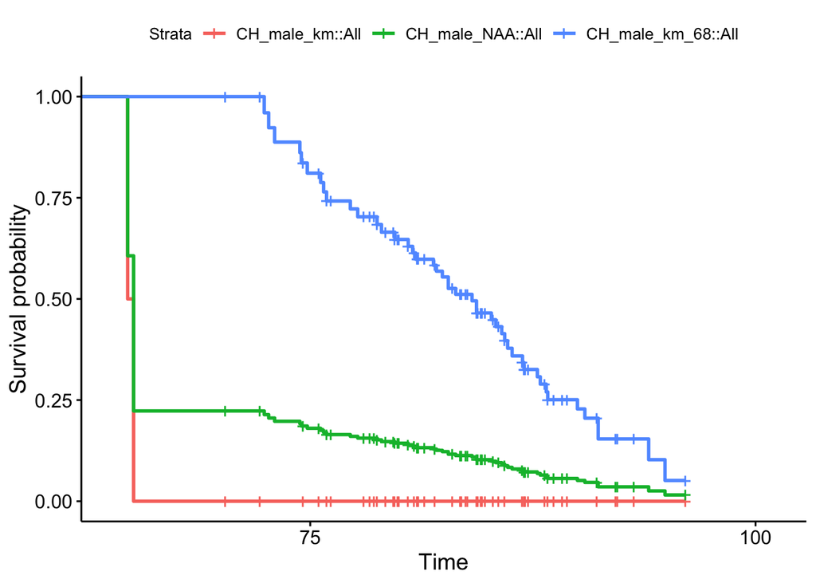

```r
ggsurvplot_combine(list(CH_male_km, CH_male_NAA, CH_male_km_68),
                   xlim = c(64, 101))
```

The red curve is the Kaplan-Meier estimate; it plunges to zero at age 65 because, at this early age, the size of the risk set is small, and in fact reduces to 0. This forces the survival curve to zero. And, since the Kaplan-Meier curve is a cumulative product, once it reaches zero it can never vary from that.  
(若い人のデータが少なくて、KM法ではこの時点でsurvivalが0になってしまうので以降は0のまま推移… 詳しくはsurv_summaryを参照)  
The NAA estimate, shown in green, is based on exponentiating a cumulative sum, so it doesn’t share this problem of going to zero early on. (NAAだと多少ましだがそれでもまだひどい)  
Still, it does take an early plunge, also due to the small size of the risk set at the younger ages. The problem here is that there is too little data to accurately estimate the overall survival distribution of men.  
Instead, we can condition on men reaching the age of 68, using the “start.time” option, and estimate the survival among that cohort (see above):  
This survival curve, shown in blue, is much better behaved. (データの少ない若年層のデータをトリムすると生存曲線はかなりいい感じになる)  
So the only solution to the problem of a small risk set with left-truncated data is to select a realistic target (here, survival of men conditional on living to age 68) for which there is sufficient data to obtain a valid estimate.

### Exercise

3.1. Find the medians urvival, and a 95% confidence interval for the median in `df`.  
Explain why the upper limit of the confidence interval is undefined.

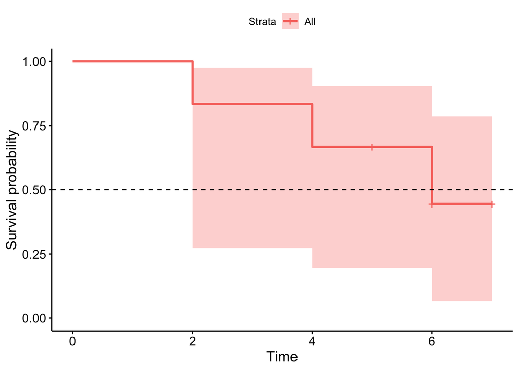

```r
# plot km from df (log-log method)
ggsurvplot(log_log_fit) %++%
  geom_hline(aes(yintercept = 0.5), linetype = "dashed")
```

```r
# extract MST and 95% C.I.
surv_median(log_log_fit)
```

```
##   strata median lower upper
## 1    All      6     2    NA
```

```r
# upper C.I. does not reach survival probability <= 50%, so median upper is undefined
```

3.2. Find the first and third quartiles, and 95% confidence intervals for these quartiles in `gastricXelox`. If any of these quantities are undefined, explain.

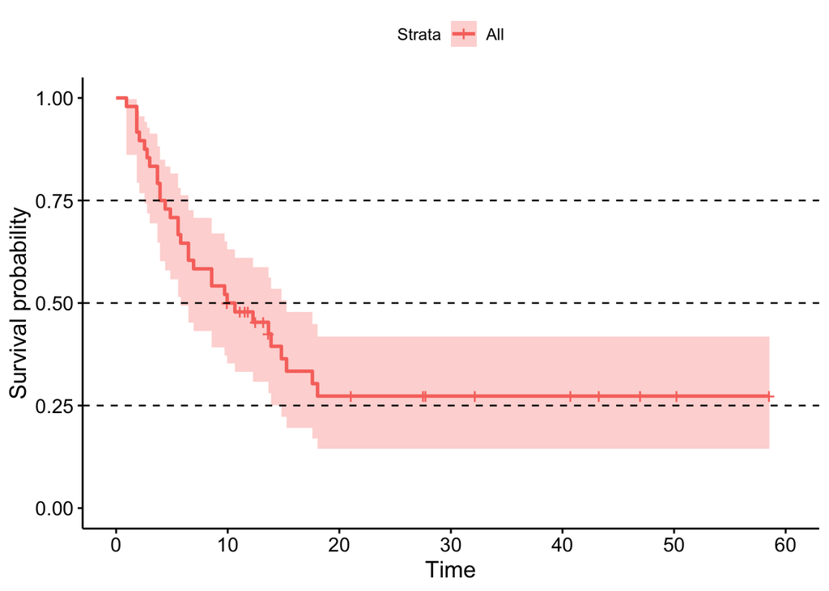

```r
# plot km_xelox
ggsurvplot(km_xelox) %++%
  geom_hline(aes(yintercept = 0.5), linetype = "dashed") %++%
  geom_hline(aes(yintercept = 0.75), linetype = "dashed") %++%
  geom_hline(aes(yintercept = 0.25), linetype = "dashed")
```

```r
df_surv_xelox <- surv_summary(km_xelox)

# median survival time
surv_median(km_xelox)
```

```
##   strata   median    lower    upper
## 1    All 10.29752 5.785124 15.27273
```

```r
# third quartiles
summarize(filter(df_surv_xelox, surv <= 0.75), first(time))
```

```
##   first(time)
## 1    3.933884
```

```r
summarize(filter(df_surv_xelox, lower <= 0.75), first(time))
```

```
##   first(time)
## 1    2.545455
```

```r
summarize(filter(df_surv_xelox, upper <= 0.75), first(time))
```

```
##   first(time)
## 1    6.479339
```

```r
# first quartiles
summarize(filter(df_surv_xelox, surv <= 0.25), first(time))
```

```
##   first(time)
## 1          NA
```

```r
summarize(filter(df_surv_xelox, lower <= 0.25), first(time))
```

```
##   first(time)
## 1    14.80992
```

```r
summarize(filter(df_surv_xelox, upper <= 0.25), first(time))
```

```
##   first(time)
## 1          NA
```

3.3. Find a smooth hazard function estimate for the gastric cancer data using kernel width “bw.grid = 20”. Explain reason for the multiple peaks in the estimate.

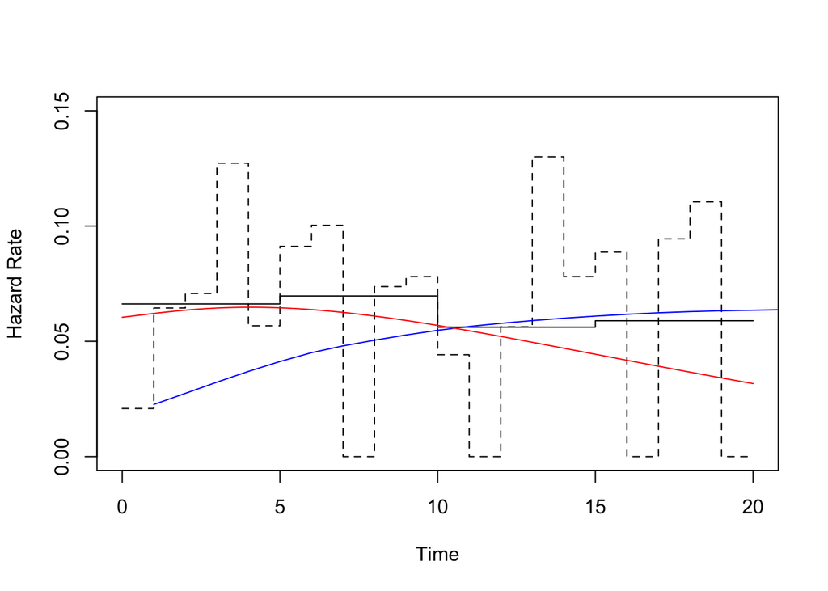

```r
# bw.smooth = 20
smooth_hazard <- muhaz(df_xelox$month, df_xelox$delta,
                       bw.smooth = 20, b.cor = "left", max.time = 20) # smooth-estimation

# extract hazard estimation
smooth_hazard_xelox <- smooth_hazard$haz.est
# extract time
smooth_time_xelox <- smooth_hazard$est.grid
# calculate survival
smooth_survival_xelox <- exp(cumsum(-smooth_hazard_xelox[1:length(smooth_hazard_xelox) - 1]) * diff(smooth_time_xelox))

# bw.grid = 20
smooth_hazard2 <- muhaz(df_xelox$month, df_xelox$delta,
                       bw.grid = 20, b.cor = "left", max.time = 20)

# extract hazard estimation
smooth_hazard_xelox2 <- smooth_hazard2$haz.est
# extract time
smooth_time_xelox2 <- smooth_hazard2$est.grid
# calculate survival
smooth_survival_xelox2 <- exp(cumsum(-smooth_hazard_xelox2[1:length(smooth_hazard_xelox2) - 1]) * diff(smooth_time_xelox2))

# hazard function
plot(pe5_hazard, ylim = c(0, 0.15))
lines(pe1_hazard)
lines(smooth_hazard_xelox, col = "blue")
lines(smooth_hazard2, col = "red")
```

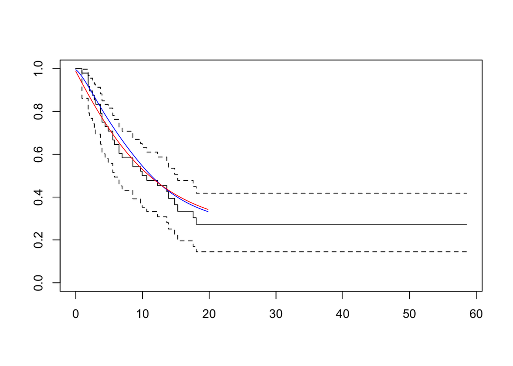

```r
# survival function
plot(km_xelox)
lines(smooth_time_xelox[1:length(smooth_time_xelox) - 1], smooth_survival_xelox, col = "blue")
lines(smooth_time_xelox2[1:length(smooth_time_xelox2) - 1], smooth_survival_xelox2, col = "red")
```

3.4. Estimate the survival distribution for men, conditional on reaching the age of 68, ignoring the left truncation times. Discuss the bias of this estimate by comparing to the estimate presented in previous data.

```r
# Extract data reaching 68 years old
CH_male_68 <- CH_male %>%
  filter(entry >= 68) %>%
  arrange(entry)

# View head
head(CH_male_68)
```

```
## # A tibble: 6 x 5
##   sex   entry  exit  time  cens
##   <fct> <dbl> <dbl> <dbl> <int>
## 1 Male   68.1  70.2  2.17     0
## 2 Male   68.3  79.8 11.4      0
## 3 Male   68.4  79.7 11.2      0
## 4 Male   68.6  80   11.4      0
## 5 Male   69.2  78.3  9.17     0
## 6 Male   69.6  75.6  6        1
```

```r
# survfit data devided by age
(CH_male_km_68_biased <- surv_fit(Surv(exit, cens) ~ 1, data = CH_male_68))
```

[output not shown]

[output cut: 25 more lines]

[output not shown]

```r
CH_male_km_68
```

[output not shown]

[output cut: 24 more lines]

[output not shown]

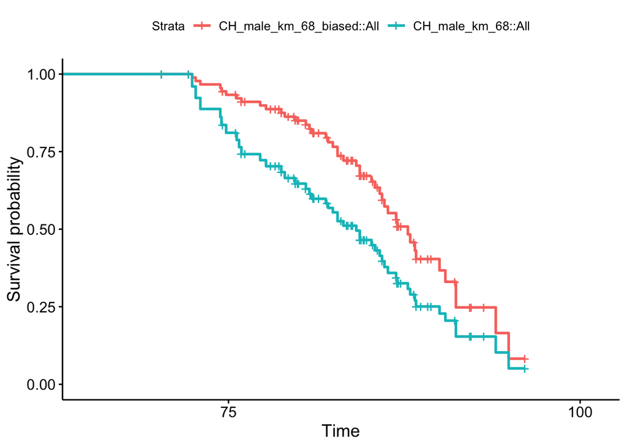

```r
# plot K-M curve ignoring left-trunc
ggsurvplot_combine(list(CH_male_km_68_biased, CH_male_km_68),
                   xlim = c(65, 101))
```